# Classification non supervisée de données morphologiques d’oiseaux

M1 MAS — Université Rennes 1

2026-04-20

# 1 Introduction et présentation des données

## 1.1 Description du jeu de données

```r
library(tidyverse)
library(cluster)
library(factoextra)
library(NbClust)
library(mclust)
```

```r
bird <- read_csv("bird.csv")
glimpse(bird)
```

```
## Rows: 420
## Columns: 12
## $ id    <dbl> 0, 1, 2, 3, 4, 5, 6, 7, 8, 9, 10, 11, 12, 13, 14, 15, 16, 17, 18…
## $ huml  <dbl> 80.78, 88.91, 79.97, 77.65, 62.80, 61.92, 79.73, 86.98, 118.20, …
## $ humw  <dbl> 6.68, 6.63, 6.37, 5.70, 4.84, 4.78, 5.94, 5.68, 7.82, 10.42, 11.…
## $ ulnal <dbl> 72.01, 80.53, 69.26, 65.76, 52.09, 50.46, 67.39, 74.52, 116.64, …
## $ ulnaw <dbl> 4.88, 5.59, 5.28, 4.77, 3.73, 3.47, 4.50, 4.55, 6.13, 7.05, 8.68…
## $ feml  <dbl> 41.81, 47.04, 43.07, 40.04, 33.95, 49.52, 42.07, 44.46, 59.33, 7…
## $ femw  <dbl> 3.70, 4.30, 3.90, 3.52, 2.72, 4.41, 3.41, 3.78, 5.45, 7.44, 7.85…
## $ tibl  <dbl> 5.50, 80.22, 75.35, 69.17, 56.27, 56.95, 71.26, 76.02, 110.00, 1…
## $ tibw  <dbl> 4.03, 4.51, 4.04, 3.40, 2.96, 2.73, 3.56, 3.81, 5.58, 7.31, 8.25…
## $ tarl  <dbl> 38.70, 41.50, 38.31, 35.78, 31.88, 29.07, 37.22, 37.94, 61.62, 7…
## $ tarw  <dbl> 3.84, 4.01, 3.34, 3.41, 3.13, 2.83, 3.64, 3.81, 4.37, 6.34, 6.63…
## $ type  <chr> "SW", "SW", "SW", "SW", "SW", "SW", "SW", "SW", "SW", "SW", "SW"…
```

Le jeu de données `bird` contient **420 observations** et **12 variables** :

| Variable | Description |
| --- | --- |
| `id` | Identifiant de l’individu |
| `huml` / `humw` | Longueur / Largeur de l’humérus (aile proximale, en mm) |
| `ulnal` / `ulnaw` | Longueur / Largeur de l’ulna (aile distale, en mm) |
| `feml` / `femw` | Longueur / Largeur du fémur (cuisse, en mm) |
| `tibl` / `tibw` | Longueur / Largeur du tibia (jambe, en mm) |
| `tarl` / `tarw` | Longueur / Largeur du tarse (pied, en mm) |
| `type` | Type écologique de l’oiseau (6 modalités) |

Les six types écologiques sont : **P** (Perching, percheur), **R** (Rapacious, rapace), **SO** (Songbird, chanteur), **SW** (Swimming, nageur), **T** (Terrestrial, terrestre) et **W** (Wading, échassier).

## 1.2 Objectif

L’objectif est d’évaluer dans quelle mesure les **caractéristiques morphologiques osseuses** permettent de distinguer automatiquement les six types écologiques, via trois méthodes de **classification non supervisée** : CAH, K-means et GMM.

La variable `type` est ignorée pendant la classification et sert uniquement à **évaluer a posteriori** la qualité des partitions obtenues.

# 2 Pré-traitement des données

## 2.1 Valeurs manquantes et nettoyage

```r
cat("Présence de valeurs manquantes :", anyNA(bird), "\n")
```

```
## Présence de valeurs manquantes : TRUE
```

```r
cat("Effectif initial :", nrow(bird), "\n")
```

```
## Effectif initial : 420
```

```r
bird_clean <- bird |>
  filter(if_all(where(is.numeric), ~ !is.na(.) & is.finite(.)))

cat("Effectif après nettoyage :", nrow(bird_clean), "\n")
```

```
## Effectif après nettoyage : 413
```

```r
cat("Lignes supprimées :", nrow(bird) - nrow(bird_clean), "\n")
```

```
## Lignes supprimées : 7
```

## 2.2 Distribution des types

```r
table(bird_clean$type)
```

```
##
##   P   R  SO  SW   T   W
##  38  48 124 116  23  64
```

## 2.3 Standardisation

Les variables `id` et `type` sont exclues. Les 10 variables morphologiques sont ensuite **standardisées** (centrées-réduites) pour neutraliser les effets d’échelle.

```r
bird_data   <- bird_clean |> select(-id, -type)
bird_scaled <- scale(bird_data)

# Vérification
round(colMeans(bird_scaled), 6)
```

```
##  huml  humw ulnal ulnaw  feml  femw  tibl  tibw  tarl  tarw
##     0     0     0     0     0     0     0     0     0     0
```

```r
round(apply(bird_scaled, 2, sd), 6)
```

```
##  huml  humw ulnal ulnaw  feml  femw  tibl  tibw  tarl  tarw
##     1     1     1     1     1     1     1     1     1     1
```

# 3 Analyse exploratoire préalable : ACP

Avant toute classification, une ACP permet de visualiser la structure des données et d’anticiper la difficulté de la tâche.

```r
pca_result <- prcomp(bird_scaled)
bird_type  <- factor(bird_clean$type)

summary(pca_result)$importance[, 1:4]
```

```
##                             PC1       PC2       PC3       PC4
## Standard deviation     2.922804 0.8094952 0.6525112 0.3523447
## Proportion of Variance 0.854280 0.0655300 0.0425800 0.0124100
## Cumulative Proportion  0.854280 0.9198100 0.9623800 0.9748000
```

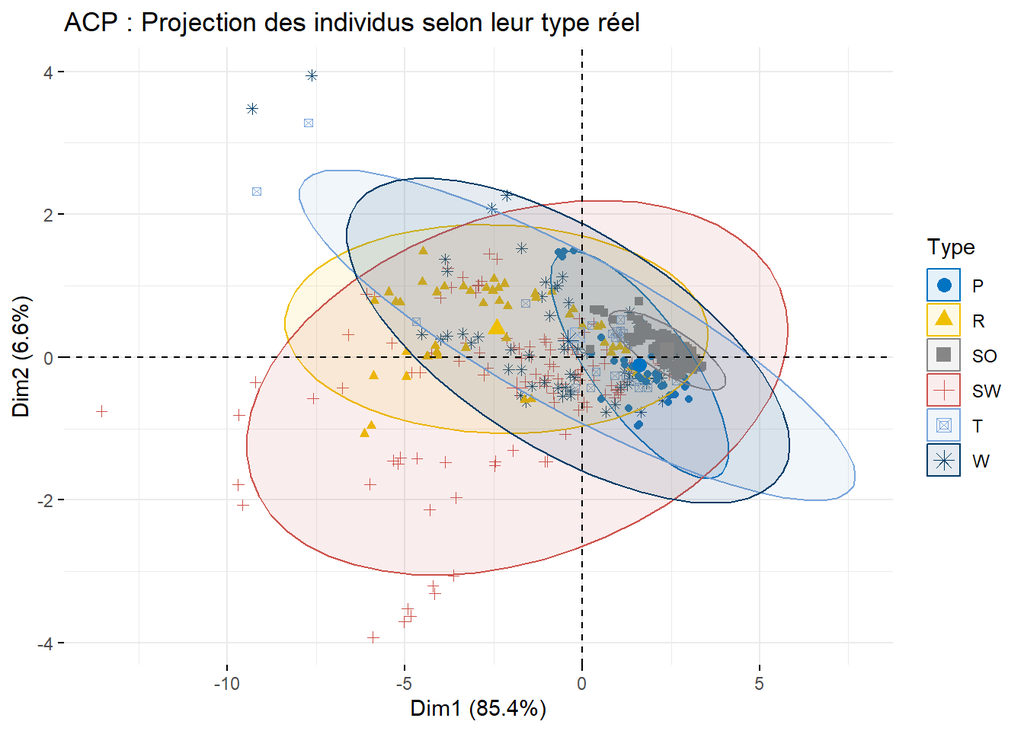

Projection des individus sur les deux premiers axes de l’ACP, colorés par type réel.

```r
fviz_pca_ind(pca_result,
             geom.ind     = "point",
             col.ind      = bird_type,
             palette      = "jco",
             addEllipses  = TRUE,
             legend.title = "Type") +
  ggtitle("ACP : Projection des individus selon leur type réel")
```

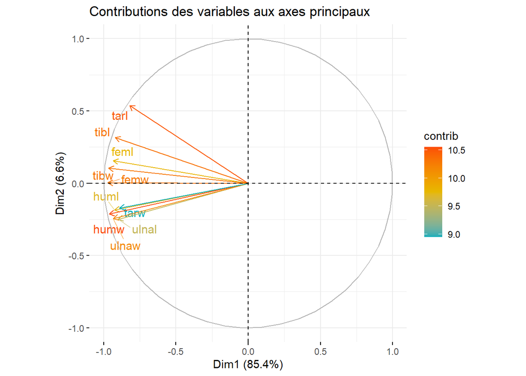

Cercle des corrélations : toutes les variables contribuent quasi-uniformément à l’axe 1.

```r
fviz_pca_var(pca_result,
             col.var       = "contrib",
             gradient.cols = c("#00AFBB", "#E7B800", "#FC4E07"),
             repel         = TRUE) +
  ggtitle("Contributions des variables aux axes principaux")
```

**Lecture de l’ACP :** L’axe 1 concentre **85,4 % de la variance totale**. Toutes les variables y contribuent de façon quasi-équivalente (flèches parallèles, même longueur) : cet axe représente la **taille corporelle globale**. L’axe 2 (6,6 %) oppose les variables de pattes (tarse, tibia, fémur) aux variables d’ailes (humérus, ulna), capturant un contraste secondaire **membres inférieurs vs supérieurs**.

# 4 Méthodes de classification non supervisée

## 4.1 Méthode 1 - Classification Ascendante Hiérarchique (CAH)

### 4.1.1 Principe

La CAH regroupe progressivement les individus par fusions successives. On utilise le **critère de Ward**, qui minimise l’accroissement d’inertie intra-classe à chaque fusion :

$$d_W(A, B) = \frac{n_A \cdot n_B}{n_A + n_B} \left\| \bar{x}_A -
\bar{x}_B \right\|^2$$

### 4.1.2 Détermination du nombre optimal de clusters

```r
distance <- dist(bird_scaled, method = "euclidean")
cah_ward <- hclust(distance, method = "ward.D2")
```

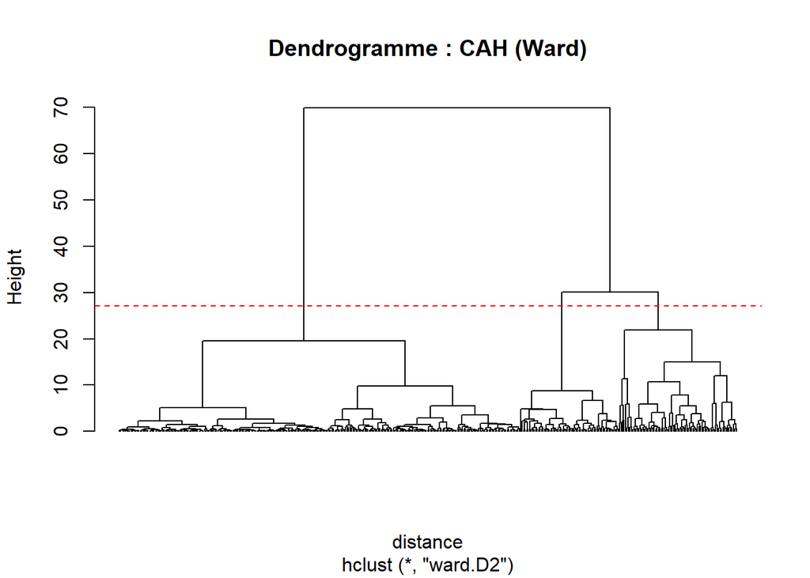

Dendrogramme CAH (Ward). La rupture la plus marquée apparaît à K=2.

```r
plot(cah_ward, labels = FALSE, hang = -1,
     main = "Dendrogramme : CAH (Ward)")
abline(h = cah_ward$height[length(cah_ward$height) - 1] * 0.9,
       col = "red", lty = 2)
```

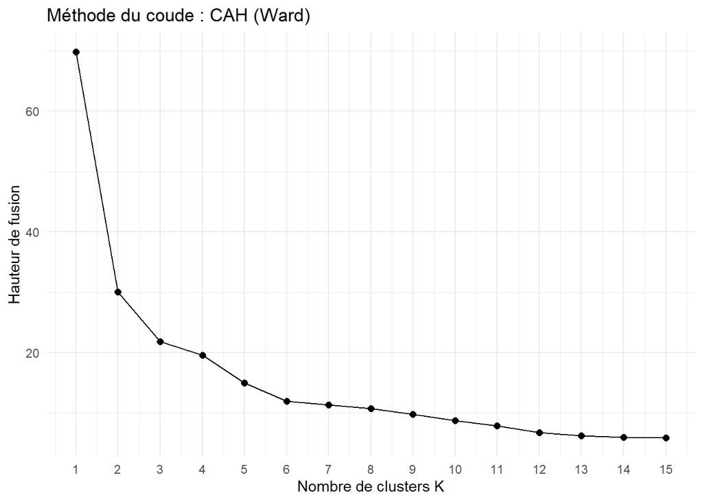

Méthode du coude : la rupture de pente la plus nette est à K=2, avec un second coude plus modéré vers K=5-6.

```r
data.frame(K = 1:15, hauteur = rev(cah_ward$height)[1:15]) |>
  ggplot(aes(x = K, y = hauteur)) +
  geom_line() +
  geom_point(size = 2) +
  scale_x_continuous(breaks = 1:15) +
  labs(title = "Méthode du coude : CAH (Ward)",
       x = "Nombre de clusters K",
       y = "Hauteur de fusion") +
  theme_minimal()
```

```r
set.seed(42)
nb_res <- NbClust(bird_scaled, distance = "euclidean",
                  method = "ward.D2", min.nc = 2, max.nc = 10)
```

```r
sort(table(nb_res$Best.nc["Number_clusters", ]), decreasing = TRUE)
```

```
##
##  2  3  0  6 10  1  4  5  7  9
##  7  5  2  2  2  1  1  1  1  1
```

Nous retenons donc **K = 2** comme partition principale. À titre exploratoire, nous examinerons également K = 6 dans une section dédiée, afin d’évaluer si cette contrainte biologique permet de mieux retrouver les types réels.

### 4.1.3 Partition à K = 2 (partition optimale)

```r
cah_k2 <- cutree(cah_ward, k = 2)
table(CAH_K2 = cah_k2, Type = bird_clean$type)
```

```
##       Type
## CAH_K2   P   R  SO  SW   T   W
##      1   4  37   0  71   4  29
##      2  34  11 124  45  19  35
```

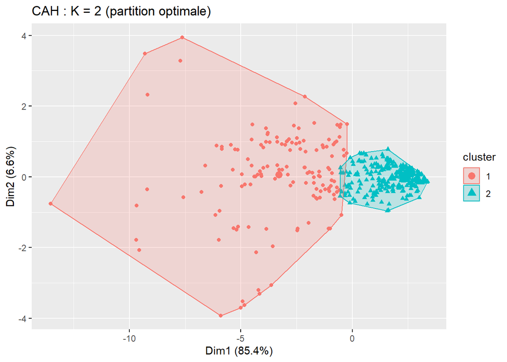

Clusters CAH K=2 dans le plan de l’ACP.

```r
fviz_cluster(list(data = bird_scaled, cluster = cah_k2),
             geom = "point", ellipse.type = "convex") +
  ggtitle("CAH : K = 2 (partition optimale)")
```

### 4.1.4 Partition à K = 6 (analyse exploratoire)

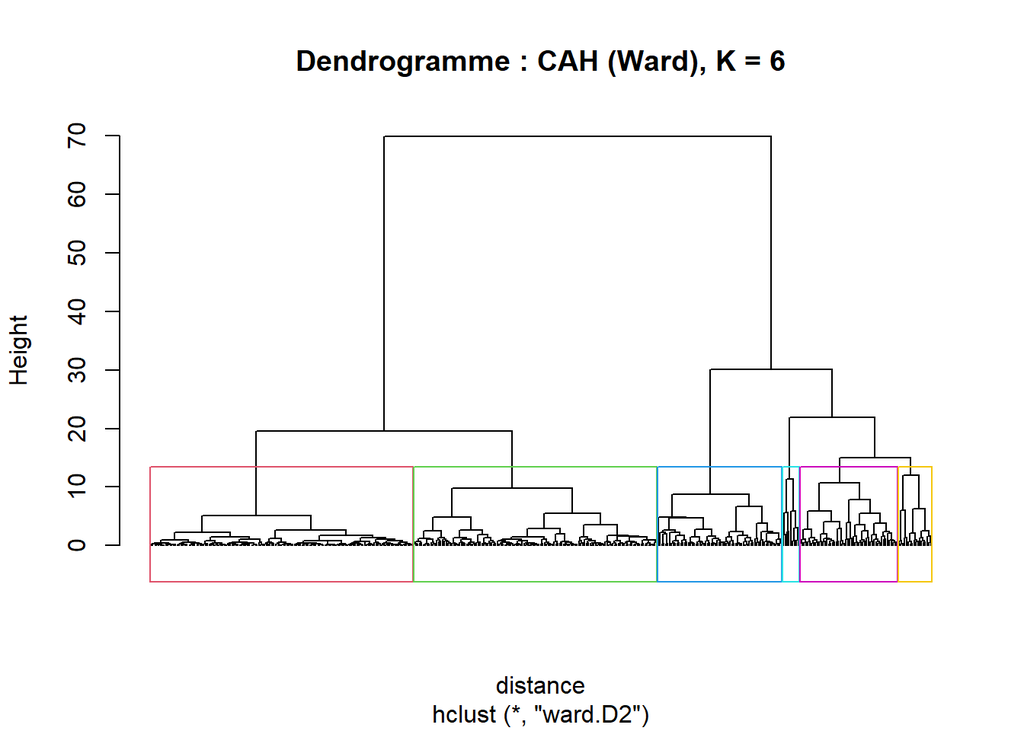

```r
cah_k6 <- cutree(cah_ward, k = 6)

plot(cah_ward, labels = FALSE, hang = -1,
     main = "Dendrogramme : CAH (Ward), K = 6")
rect.hclust(cah_ward, k = 6, border = 2:7)
```

```r
table(CAH_K6 = cah_k6, Type = bird_clean$type)
```

```
##       Type
## CAH_K6  P  R SO SW  T  W
##      1  4 18  0 24  1 19
##      2 17 11 26 35 18 22
##      3  0 19  0 24  1  8
##      4  0  0  0 18  0  0
##      5  0  0  0  5  2  2
##      6 17  0 98 10  1 13
```

## 4.2 Méthode 2 - K-means

### 4.2.1 Principe

Le K-means partitionne les individus en $K$ groupes en minimisant l’inertie intra-classe :

$$W(K) = \sum_{k=1}^{K} \sum_{i \in C_k} \left\| x_i - \bar{x}_k
\right\|^2$$

L’initialisation étant aléatoire, on répète l’algorithme 50 fois (`nstart = 50`) et on retient la meilleure solution.

### 4.2.2 Choix de K par la méthode du coude

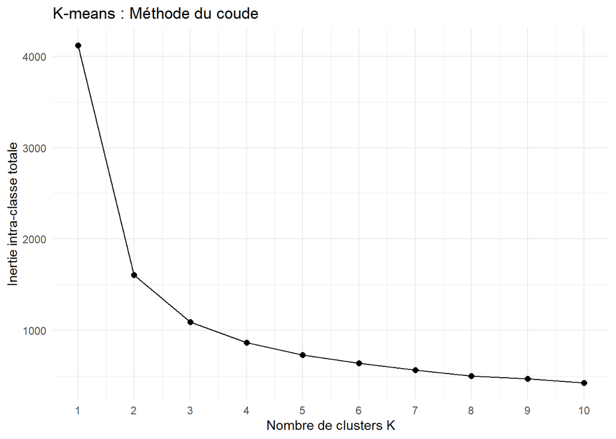

Inertie intra-classe en fonction de K : rupture nette à K=2.

```r
set.seed(42)
inertie <- map_dbl(1:10, ~ kmeans(bird_scaled, centers = .x, nstart = 50)$tot.withinss)

data.frame(K = 1:10, inertie = inertie) |>
  ggplot(aes(x = K, y = inertie)) +
  geom_line() +
  geom_point(size = 2) +
  scale_x_continuous(breaks = 1:10) +
  labs(title = "K-means : Méthode du coude",
       x = "Nombre de clusters K",
       y = "Inertie intra-classe totale") +
  theme_minimal()
```

La courbe confirme une rupture nette à **K = 2**, cohérente avec les résultats de la CAH.

### 4.2.3 Partition à K = 2 (partition optimale)

```r
set.seed(456)
km_k2 <- kmeans(bird_scaled, centers = 2, nstart = 50)
table(Kmeans_K2 = km_k2$cluster, Type = bird_clean$type)
```

```
##          Type
## Kmeans_K2   P   R  SO  SW   T   W
##         1  38  14 124  61  19  44
##         2   0  34   0  55   4  20
```

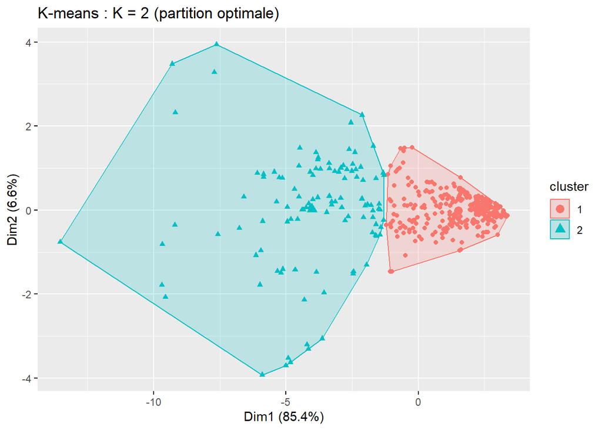

Clusters K-means K=2 dans le plan de l’ACP.

```r
fviz_cluster(km_k2, data = bird_scaled,
             geom = "point", ellipse.type = "convex") +
  ggtitle("K-means : K = 2 (partition optimale)")
```

### 4.2.4 Partition à K = 6 (analyse exploratoire)

```r
set.seed(456)
km_k6 <- kmeans(bird_scaled, centers = 6, nstart = 50)
table(Kmeans_K6 = km_k6$cluster, Type = bird_clean$type)
```

```
##          Type
## Kmeans_K6   P   R  SO  SW   T   W
##         1   0  24   0  21   1  10
##         2  17   0 100  10   1  13
##         3   4  10   0  39   2  26
##         4  17  10  24  20  17  13
##         5   0   0   0   8   2   2
##         6   0   4   0  18   0   0
```

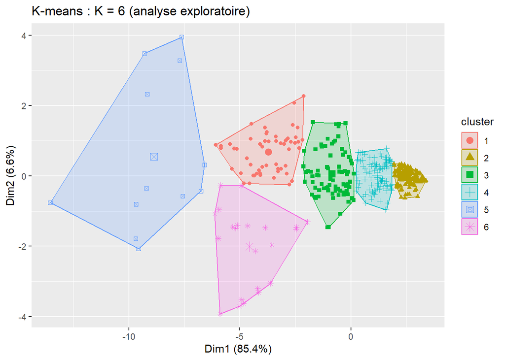

Clusters K-means K=6 dans le plan de l’ACP.

```r
fviz_cluster(km_k6, data = bird_scaled,
             geom = "point", ellipse.type = "convex") +
  ggtitle("K-means : K = 6 (analyse exploratoire)")
```

## 4.3 Méthode 3 - Modèle de Mélanges Gaussiens (GMM)

### 4.3.1 Principe

Le GMM suppose que les données sont générées par un **mélange de $G$ lois gaussiennes multivariées**. Chaque individu reçoit une probabilité d’appartenance à chaque groupe (classification souple). Les paramètres sont estimés par l’algorithme **EM**, et $G$ ainsi que la structure de covariance sont sélectionnés par le **BIC**.

```r
gmm_model <- Mclust(bird_scaled, verbose = FALSE)
summary(gmm_model)
```

```
## ----------------------------------------------------
## Gaussian finite mixture model fitted by EM algorithm
## ----------------------------------------------------
##
## Mclust VEE (ellipsoidal, equal shape and orientation) model with 9 components:
##
##  log-likelihood   n  df     BIC      ICL
##        1255.417 413 161 1541.06 1492.088
##
## Clustering table:
##  1  2  3  4  5  6  7  8  9
## 15 84 41 33 58 34 65 14 69
```

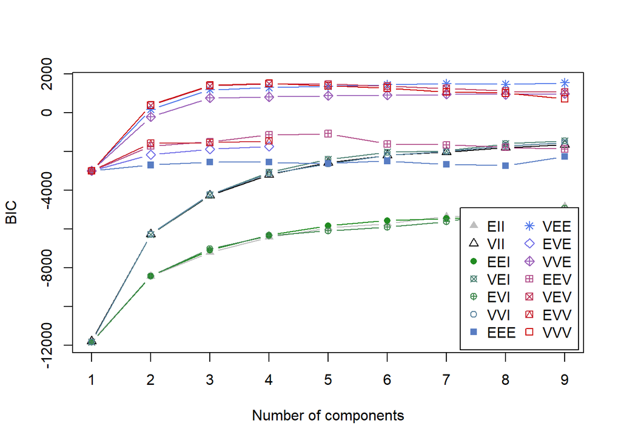

Valeurs de BIC selon le modèle et le nombre de composantes. Le maximum désigne la solution optimale.

```r
plot(gmm_model, what = "BIC")
```

Le modèle sélectionné automatiquement est de type **VEE** avec **9 composantes**. Pour une comparaison équitable avec K = 2 (recommandé par la CAH et le K-means), nous ajustons également un GMM à G = 2 :

```r
gmm_g2 <- Mclust(bird_scaled, G = 2, verbose = FALSE)
cat("BIC : GMM libre (G =", gmm_model$G, ") :", round(max(gmm_model$BIC, na.rm = TRUE), 1), "\n")
```

```
## BIC : GMM libre (G = 9 ) : 1541.1
```

```r
cat("BIC : GMM G=2             :", round(gmm_g2$bic, 1), "\n")
```

```
## BIC : GMM G=2             : 393.6
```

```r
cat("BIC : GMM G=6             :")
```

```
## BIC : GMM G=6             :
```

```r
gmm_g6 <- Mclust(bird_scaled, G = 6, verbose = FALSE)
cat(round(gmm_g6$bic, 1), "\n")
```

```
## 1455.4
```

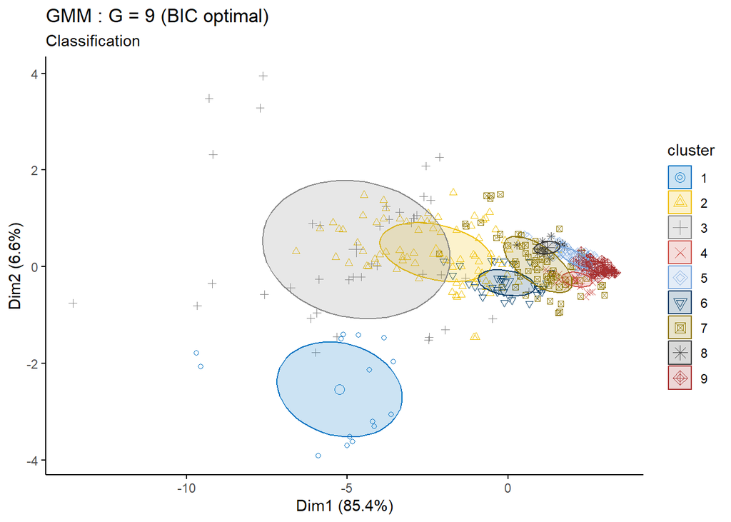

Clusters GMM (G optimal) dans le plan des deux premiers axes de l’ACP.

```r
fviz_mclust(gmm_model, what = "classification", geom = "point",
            palette = "jco") +
  ggtitle(paste0("GMM : G = ", gmm_model$G, " (BIC optimal)"))
```

```r
cat("GMM G optimal (G =", gmm_model$G, ")")
```

```
## GMM G optimal (G = 9 )
```

```r
print(table(GMM_opt = gmm_model$classification, Type = bird_clean$type))
```

```
##        Type
## GMM_opt  P  R SO SW  T  W
##       1  0  0  0 15  0  0
##       2  0 26  0 34  2 22
##       3  0  5  0 29  2  5
##       4 21  0  9  0  3  0
##       5  0  0 43  8  0  7
##       6  0  0  0 22  0 12
##       7 15 17  5  8  7 13
##       8  2  0  0  0  9  3
##       9  0  0 67  0  0  2
```

```r
cat("\nGMM G=2")
```

```
##
## GMM G=2
```

```r
print(table(GMM_G2 = gmm_g2$classification, Type = bird_clean$type))
```

```
##       Type
## GMM_G2   P   R  SO  SW   T   W
##      1  11  45   2 106   6  47
##      2  27   3 122  10  17  17
```

```r
cat("\nGMM G=6")
```

```
##
## GMM G=6
```

```r
print(table(GMM_G6 = gmm_g6$classification, Type = bird_clean$type))
```

```
##       Type
## GMM_G6  P  R SO SW  T  W
##      1  0  5  0 46  2  4
##      2  0 26  0 31  2 23
##      3  0  0 65  0  0  2
##      4 24  0 53 10  2  9
##      5  0  0  0 26  0 12
##      6 14 17  6  3 17 14
```

# 5 Comparaison et évaluation des méthodes

## 5.1 Adjusted Rand Index (ARI)

L’ARI mesure la concordance entre la partition obtenue et les vraies étiquettes, corrigée pour le hasard (0 = aléatoire, 1 = parfait).

```r
type_num <- as.numeric(factor(bird_clean$type))

ari_results <- tibble(
  Méthode    = c("CAH K=2", "CAH K=6",
                 "K-means K=2", "K-means K=6",
                 paste0("GMM G=", gmm_model$G, " (opt.)"),
                 "GMM G=2", "GMM G=6"),
  K          = c(2, 6, 2, 6, gmm_model$G, 2, 6),
  ARI        = round(c(
    adjustedRandIndex(cah_k2,                 type_num),
    adjustedRandIndex(cah_k6,                 type_num),
    adjustedRandIndex(km_k2$cluster,          type_num),
    adjustedRandIndex(km_k6$cluster,          type_num),
    adjustedRandIndex(gmm_model$classification, type_num),
    adjustedRandIndex(gmm_g2$classification,  type_num),
    adjustedRandIndex(gmm_g6$classification,  type_num)
  ), 3)
)

knitr::kable(ari_results, caption = "ARI de chaque méthode et partition")
```

ARI de chaque méthode et partition

| Méthode | K | ARI |
| --- | --- | --- |
| CAH K=2 | 2 | 0.160 |
| CAH K=6 | 6 | 0.203 |
| K-means K=2 | 2 | 0.107 |
| K-means K=6 | 6 | 0.241 |
| GMM G=9 (opt.) | 9 | 0.260 |
| GMM G=2 | 2 | 0.308 |
| GMM G=6 | 6 | 0.261 |

## 5.2 Description morphologique des groupes

Cette section décrit les profils moyens de chaque cluster pour les deux partitions principales (K=2 et K=6 pour K-means, à titre comparatif).

```r
cat("Profils morphologiques moyens : K-means K=2")
```

```
## Profils morphologiques moyens : K-means K=2
```

```r
round(aggregate(bird_data, by = list(Cluster = km_k2$cluster), mean), 1)
```

```
##   Cluster  huml humw ulnal ulnaw feml femw  tibl tibw tarl tarw
## 1       1  40.1  3.0  42.6   2.5 27.2  2.2  46.4  2.1 29.5  1.9
## 2       2 130.8  8.1 139.9   6.5 62.3  6.0 113.0  6.0 65.4  5.7
```

```r
cat(" Profils morphologiques moyens : K-means K=6")
```

```
##  Profils morphologiques moyens : K-means K=6
```

```r
round(aggregate(bird_data, by = list(Cluster = km_k6$cluster), mean), 1)
```

```
##   Cluster  huml humw ulnal ulnaw feml femw  tibl tibw  tarl tarw
## 1       1 119.3  7.1 125.2   5.8 62.1  5.9 119.4  6.2  72.7  5.1
## 2       2  22.6  2.0  26.0   1.7 19.1  1.5  32.8  1.4  22.1  1.2
## 3       3  81.7  5.2  83.4   4.5 42.9  3.6  76.6  3.7  46.7  3.2
## 4       4  42.7  3.3  44.8   2.8 31.1  2.4  50.3  2.4  31.1  2.2
## 5       5 235.8 12.9 247.3   8.8 91.4  8.7 179.2  9.0 112.4  7.7
## 6       6 143.9 10.1 166.3   8.2 60.4  6.7  88.1  5.7  35.1  8.4
```

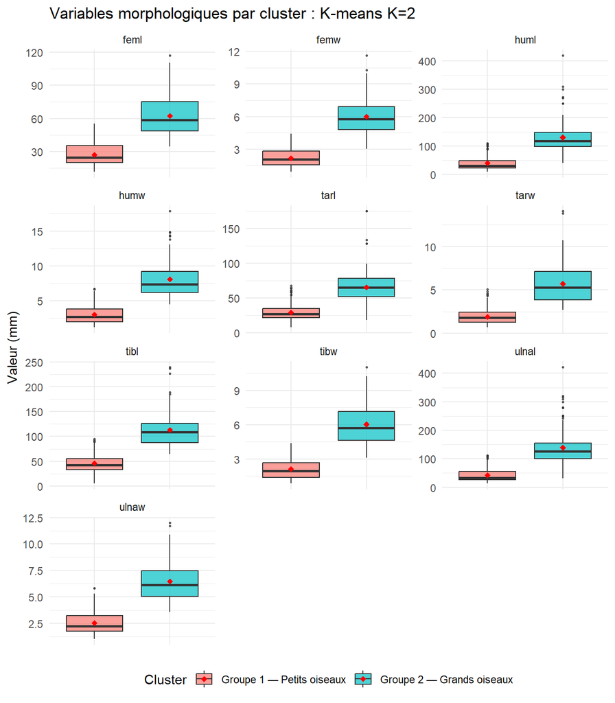

Distribution des variables morphologiques par cluster K-means K=2. Les points rouges indiquent les moyennes.

```r
bird_data |>
  mutate(Cluster = factor(km_k2$cluster,
                          labels = c("Groupe 1 — Petits oiseaux",
                                     "Groupe 2 — Grands oiseaux")[sort(unique(km_k2$cluster))])) |>
  pivot_longer(-Cluster, names_to = "variable", values_to = "valeur") |>
  ggplot(aes(x = Cluster, y = valeur, fill = Cluster)) +
  geom_boxplot(outlier.size = 0.5, alpha = 0.7) +
  stat_summary(fun = mean, geom = "point", shape = 18, size = 2, color = "red") +
  facet_wrap(~ variable, scales = "free_y", ncol = 3) +
  labs(title = "Variables morphologiques par cluster : K-means K=2",
       x = NULL, y = "Valeur (mm)") +
  theme_minimal() +
  theme(legend.position = "bottom", axis.text.x = element_blank())
```

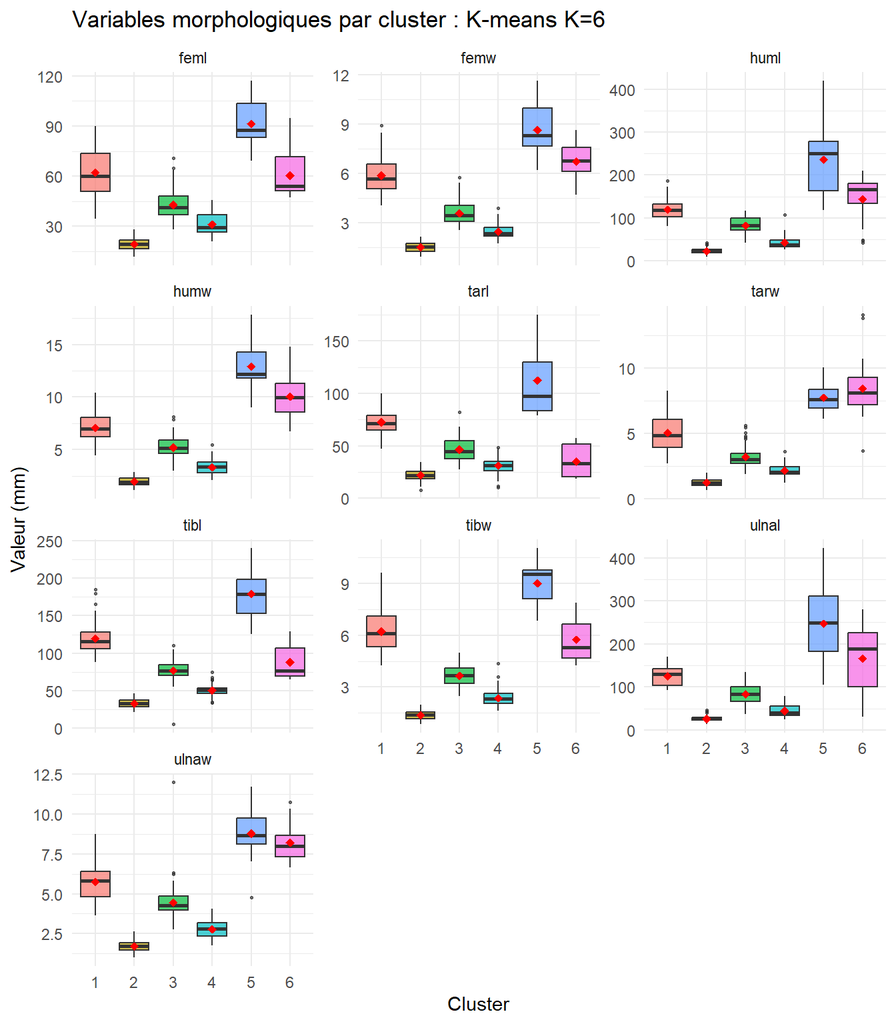

Distribution des variables morphologiques par cluster K-means K=6 (analyse exploratoire).

```r
bird_data |>
  mutate(Cluster = factor(km_k6$cluster)) |>
  pivot_longer(-Cluster, names_to = "variable", values_to = "valeur") |>
  ggplot(aes(x = Cluster, y = valeur, fill = Cluster)) +
  geom_boxplot(outlier.size = 0.5, alpha = 0.7) +
  stat_summary(fun = mean, geom = "point", shape = 18, size = 2, color = "red") +
  facet_wrap(~ variable, scales = "free_y", ncol = 3) +
  labs(title = "Variables morphologiques par cluster : K-means K=6",
       x = "Cluster", y = "Valeur (mm)") +
  theme_minimal() +
  theme(legend.position = "none")
```

### 5.2.1 Interprétation des profils morphologiques

**Partition à K = 2 :** La partition optimale révèle une opposition claire entre deux profils morphologiques :

[output not shown]

La séparation est quasi-parfaite selon la taille corporelle globale. Elle confirme que la première dimension de variation dans les données est un **gradient de taille**, non un signal de type écologique.

**Partition à K = 6 (exploratoire) :** En forçant six groupes, les clusters se subdivisent progressivement selon la taille, produisant un continuum de gabarits plutôt que six profils écologiquement distincts. Seuls les chanteurs (SO) et certains nageurs (SW) extrêmes sont isolés de façon cohérente, les autres types restant mélangés dans des clusters de taille intermédiaire.

# 6 Discussion et conclusion

## 6.1 Synthèse comparative

```r
knitr::kable(
  ari_results,
  caption = "Récapitulatif des ARI par méthode et nombre de clusters"
)
```

Récapitulatif des ARI par méthode et nombre de clusters

| Méthode | K | ARI |
| --- | --- | --- |
| CAH K=2 | 2 | 0.160 |
| CAH K=6 | 6 | 0.203 |
| K-means K=2 | 2 | 0.107 |
| K-means K=6 | 6 | 0.241 |
| GMM G=9 (opt.) | 9 | 0.260 |
| GMM G=2 | 2 | 0.308 |
| GMM G=6 | 6 | 0.261 |

## 6.2 Interprétation globale

Plusieurs enseignements se dégagent de cette analyse.

**Le GMM à G optimal sélectionne 9 composantes**, révélant une hétérogénéité plus fine que les 6 catégories. Les clusters GMM correspondent à des sous-populations morphologiques au sein des grands groupes — ce qui est informatif biologiquement mais ne coïncide pas avec la classification écologique.

## 6.3 Conclusion

La classification non supervisée basée sur les seules mesures osseuses ne permet pas de reconstituer les six catégories écologiques d’oiseaux. Cette limite est structurelle : les données varient quasi-exclusivement selon une dimension de taille corporelle, alors que les types écologiques croisent cette dimension sans s’y réduire (un rapace et un échassier peuvent avoir des mesures similaires).

Ce résultat n’est pas un échec des méthodes : il souligne que **les variables disponibles ne sont pas suffisamment discriminantes** pour ce problème à six classes. Des pistes d’amélioration seraient d’intégrer des variables de forme (ratios longueur/largeur, rapport aile/patte) qui capturent la morphologie indépendamment de la taille, ou de recourir à une approche supervisée exploitant les étiquettes connues.